# Your Digest for Monday, Aug 21, 2023 11:59 PM

## Sulfonylureas

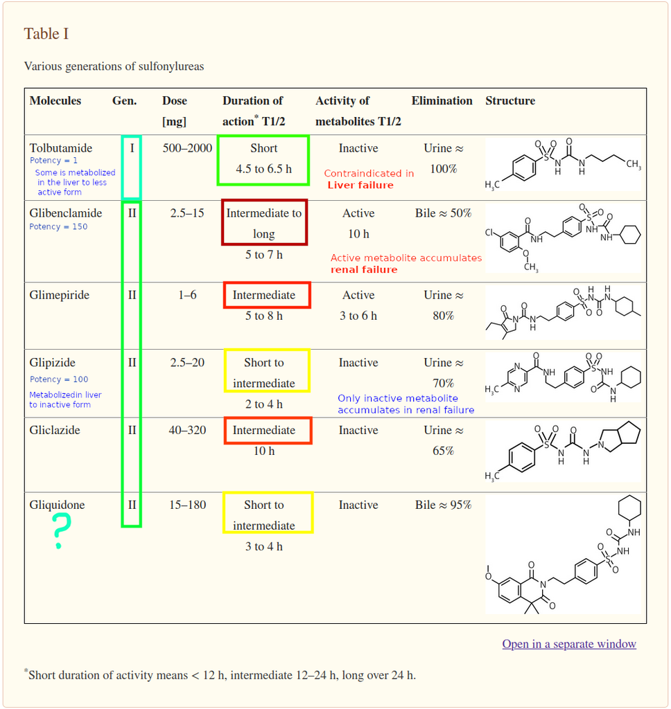

### Background

First ones used therapeutically - **Tolbutamide**. - First generation.  
Second generation - **glibenclamide, glipizide**. - more potent but produced similar degree of blood sugar control to Gen 1.

### Mechanism

Block of K+ ATP channels by sulphonylureas -> depolarization of beta cell -> Calcium influx -> Insulin secretion.

Well absorbed after oral administration. All are highly bound to albumin.  
[[General Pharmacology#Protein bound drugs]]  
Excreted in the urine unchanged or as metabolites: **action prolonged in renal disease**.  
**Contraindicated in #pregnancy** -> Crosses placenta AND appears in breastmilk.

#2022GM-MAY Q17  
It is one of the 3 types of non leukemic myeloproliferative neoplasm:

1. polycythemia vera
2. Essential thrombocythaemia
3. Primary myelofibrosis

> The **main feature of myelofibrosis** is Progressive reactive *fibrosis of the bone marrow* in association with *myeloid metaplasia* (development of haemopoiesis in the spleen and liver.

This leads to **anaemia** and **massive splenomegaly**.  
Median survival is around 5 years only! 😢  
| Mutation -> Activation of *JAK-STAT Pathway* -> increased cell production - Cont; *50% of cases are associated with JAK/STAT mutations* | Develops from essential thrombocythemia or polycythemia vera |  
| **SYmptoms:** Bone pain, fever,**itching**, weight loss, **hepatosplenomegaly** (EMH), frequent infections(↓WBC), DVT, Pulmonary embolism (**↑PLT**) | |  
| **Blood picture**: *Leukoerythroblastic blood picture*, immature red blood cells, **Marrow biopsy**: initially increased cellularity, later fibrosis | |  
| **FBC**: leukocytosis and thrombocytosis at presentation but later leucopenia and thrombocytopenia | |

## JAK-STAT pathway

The Janus Associated Kinase proteins are proteins that are coupled to growth signal receptors on haematopoietic cells. When the receptors bind growth factors, they active the JAK proteins which in turn activate the STAT family of signal transducers. STAT dimers active transcription of specific genes.  
The major pathways of similar signalling are

- JAK/STAT
- MAP
- PI3 kinase pathways.

## Symptoms

Symptoms of anaemia  
Symptoms arising from massive splenomegaly  
*"hypermatabolic" symptoms* - fever, weight loss, night sweats, anorexia

## Treatment

Aims are to reduce the effect of

1. anaemia - blood transfusions and regular folic acid.
2. and splenomegaly. - Ruloxitinib - oral JAK2 inhibitor; can reduce spleen size.

#2022GM-MAY Q17

## Chronic lymphocytic leukemia

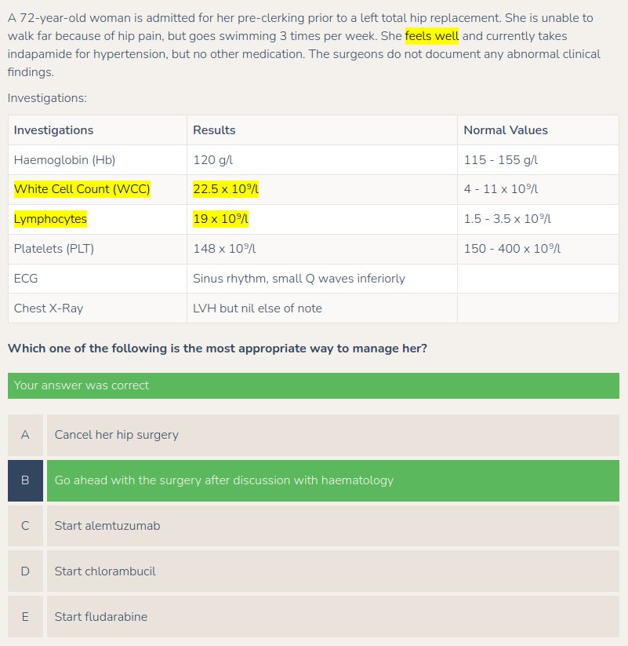

**Felty's syndrome**:  
The triad of splenomegaly, rheumatoid arthritis and neutropenia.

# Carbapenems

> . Among the β-lactams currently available, carbapenems are unique because they are *relatively resistant to hydrolysis by most β-lactamases*, in some cases act as “slow substrates” or *inhibitors of β-lactamases*

> Among beta lactams, carbapenems possess the broadest spectrum of activity and greatest potency against Gram-positive and Gram-negative bacteria

Carbapenems were discovered as a result of the search for beta lactamase inhibitors around 1970. (As beta lactamases were threatening the usefulness of penicillin at this time)

Thienamycin was a beta lactamase inhibitors that proved to be the parent molecule for all the Carbapenems.

Remarkably, thienamycin demonstrated potent broad-spectrum antibacterial and β-lactamase inhibitory activity including inhibitory microbiological activity against

1. Gram-negative bacteria, including isolates of *Pseudomonas aeruginosa*, as well as
2. anaerobes, like *Bacteroides fragilis*, and
3. Gram-positive bacteria, such as *methicillin- or oxacillin-susceptible* *Staphylococcus aureus* and streptococci  
   Imipenem (synthesized around 1985) was the first practically usable derivative of thienamycin.  
   (Imipenem is broken down by a renal brush border enzyme)

Generally speaking, carbapenems enter Gram-negative bacteria through outer membrane proteins (OMPs), also known as porins.

Meropenem, biapenem, ertapenem, and doripenem are slightly more effective against Gram-negative organisms

(i) ertapenem has a more limited spectrum, because it is not as active as imipenem or meropenem against P. aeruginosa (164); (ii) meropenem is not as potent as imipenem or doripenem against Acinetobacter baumannii (164);

unique application of meropenem is that when combined with clavulanic acid, it is potent at killing MDR Mycobacterium tuberculosis, a bacterium that typically is not susceptible to β-lactams due to a chromosomally expressed β-lactamase.

**Many class A β-lactamases are susceptible to inhibition by clavulanic acid (26). In contrast, all class C and most class D β-lactamases are not inhibited by clavulanic acid. However, class A and C and certain class D enzymes are inhibited by carbapenems. **

Several carbapenems were designed to target MRSA while maintaining activity against most Gram-negatives. The anti-MRSA activity is related to the high affinity of these compounds for PBP2a of MRSA. However, research on these compounds have been mostly abandoned. (Except for two)

The protein bound from and free form of drugs are in equilibrium. The bound form acts as a reservoir. **The unbound form is active** and also subject to elimination.

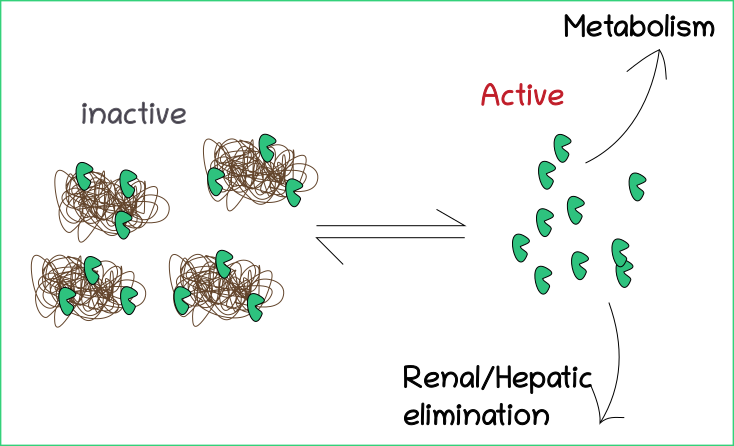

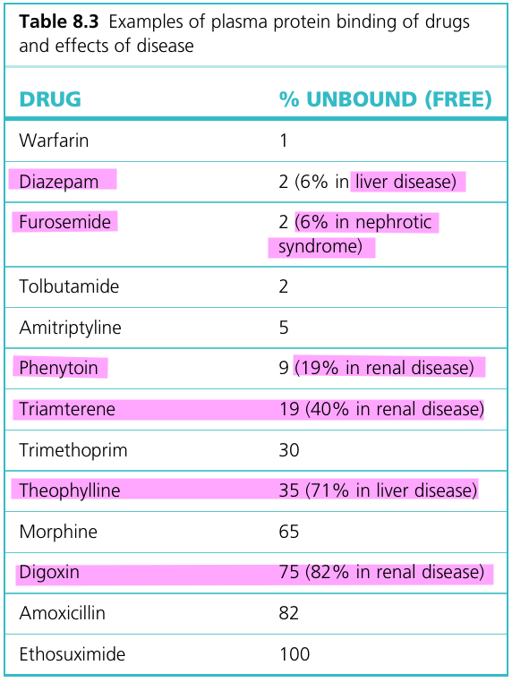

**For most drugs at therapeutic concentration, the carrier proteins are very far from saturated.**

> HRZE are **ALL** **SAFE** in #pregnancy even though many of them **do cross the placenta**.  
> Streptomycin should be avoided due to risk of auditory nerve damage and nephrotoxicity to the foetus.